# Predicting How Well Weight Lifting Was Done

Ying Li

## Synopsis

In this analysis we aim to predict how well people do certain physical activities. We use data from accelerometers on the belt, forearm, arm, and dumbell with participants who were asked to perform barbell lifts correctly and incorrectly in 5 different ways. We conducted basic analysis on the data and built prediction models, and made predictions on test data set. We can achieve out of sample accuracy of 99%, we also explored models that took less time to train but achieve lower out-of-sample accuracy.

## Data processing and exploration

The original data was from http://groupware.les.inf.puc-rio.br/har. The section of the webpage on the Weight Lifting Exercise Dataset, together with the paper http://groupware.les.inf.puc-rio.br/public/papers/2013.Velloso.QAR-WLE.pdf, provided some useful explanation on the participants’ activities recorded in the data. We obtain training data and test data from the locations provided by the course:

```r
trainingDataUrl <- "https://d396qusza40orc.cloudfront.net/predmachlearn/pml-training.csv";localTrainingFileName <- "./TrainingData.csv"
testingDataUrl <- "https://d396qusza40orc.cloudfront.net/predmachlearn/pml-testing.csv";localTestingFileName <- "./TestingData.csv"
download.file(trainingDataUrl, destfile=localTrainingFileName, method = "curl", quiet=TRUE)
download.file(testingDataUrl, destfile=localTestingFileName, method = "curl", quiet=TRUE)
training<-read.csv(localTrainingFileName)
testing<-read.csv(localTestingFileName)
```

We inspected data and noticed that the training dataset has many NA’s and empty cells. The below queries tell us that if a column has any NA, then over 97% of its content is NA. Same for empty cells.

```r
length(which(colSums(is.na(training))>0)) == length(which(colSums(is.na(training))>nrow(training)*0.97))
length(which(colSums(training =="")>nrow(training)*0.97)) == length(which(colSums(training =="")>0))
```

[output not shown]

We plot the number of NA’s per variable and number of empty cells per variable by the variable index, it confirms that the variables that have any significant NA’s and empty cells are those identified in the above queries.

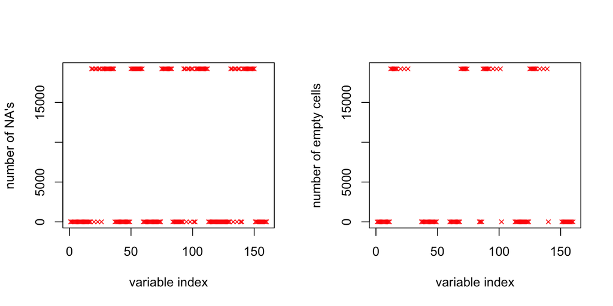

```r
par(mfrow=c(1,2))
plot(colSums(is.na(training)),xlab="variable index", ylab="number of NA's", pch=4,col="red",cex=0.7)
plot(colSums(training ==""), xlab="variable index", ylab="number of empty cells", pch=4, col="red",cex=0.7)
```

We believe that a variable with this significant amount of NA’s and empty cells should not be included in modeling. Imputing would not provide reasonable reconciliation. As such, we decided to remove those columns from training of models:

```r
NAIndex <- unique(c(which(colSums(is.na(training))>0.97), which(colSums(training =="")>nrow(training)*0.97)))
training1 <- data.frame(training[,-NAIndex])
```

## Model building and cross-validation

The data recorded six young health participants’ performance of the Unilateral Dumbbell Biceps Curl in five different fashions: exactly according to the specification (Class A), throwing the elbows to the front (Class B), lifting the dumbbell only halfway (Class C), lowering the dumbbell only halfway (Class D) and throwing the hips to the front (Class E). We want to build a model to predict the class of performance based on measurement data.

We use random forest to model the classes: we first partition the training data to hold off a cross validation dataset. We train the model on the training partition and compute accuracy on hold off test partition.

```r
set.seed(217)
inTrain <- createDataPartition(y=training1$classe,p=0.7, list=FALSE)
cx_training <- training1[inTrain,]
cx_testing <- training1[-inTrain,]
## modFit <- train(classe~ .,data=cx_training[,7:60],method="rf")
## save(modFit, file="~/datasciencecoursera/PracticalMachineLearning/PMLProject/save.modfit_fullData70Percent.save")
# I used eval=-(5:6) to skip the model training step during html compile and load the model already built at html compile time
load("~/datasciencecoursera/PracticalMachineLearning/PMLProject/save.modfit_fullData70Percent.save")
```

We then perform cross-validation on hold-off test partition and show the confusion matrix:

```r
pred <- predict(modFit, newdata=cx_testing)
confusionMatrix(pred, cx_testing$classe)
```

```
## Confusion Matrix and Statistics
##
##           Reference
## Prediction    A    B    C    D    E
##          A 1672    1    0    0    0
##          B    1 1138    2    0    0
##          C    0    0 1024    1    0
##          D    0    0    0  963    0
##          E    1    0    0    0 1082
##
## Overall Statistics
##
##                Accuracy : 0.999
##                  95% CI : (0.9978, 0.9996)
##     No Information Rate : 0.2845
##     P-Value [Acc > NIR] : < 2.2e-16
##
##                   Kappa : 0.9987
##  Mcnemar's Test P-Value : NA
##
## Statistics by Class:
##
##                      Class: A Class: B Class: C Class: D Class: E
## Sensitivity            0.9988   0.9991   0.9981   0.9990   1.0000
## Specificity            0.9998   0.9994   0.9998   1.0000   0.9998
## Pos Pred Value         0.9994   0.9974   0.9990   1.0000   0.9991
## Neg Pred Value         0.9995   0.9998   0.9996   0.9998   1.0000
## Prevalence             0.2845   0.1935   0.1743   0.1638   0.1839
## Detection Rate         0.2841   0.1934   0.1740   0.1636   0.1839
## Detection Prevalence   0.2843   0.1939   0.1742   0.1636   0.1840
## Balanced Accuracy      0.9993   0.9992   0.9989   0.9995   0.9999
```

We see this model is of good quality with out-of-sample accuracy of 99.9% with high confidence. We also tried partition rate of 0.9, the out-of-sample accuracy is about 99.6%.

However, it took very long time to train the model. Upon further inspection of the data, we noticed that the variable “num_window” has a direct relationship with variable “classe”, the outcome we want to predict. We decided to try build a model with variable values averaged for each value of num_window and build a new model. We know this time it will take much less time to build the model as the data size is significantly smaller. But we can see from cross-validation that this model is less accurate, with 91.7% out-of-sample accuracy which may still be useful.

```r
trainingNew <-aggregate(data.frame(training1[,7:59]), by=list(num_window=training1$num_window), FUN = mean)
trainingNew <- trainingNew[,-1]
label<-unique(training[,c(7,160)])
trainingData <- merge(x = trainingNew, y = label, by = "num_window", all = TRUE)
set.seed(217)
inTrain <- createDataPartition(y=trainingData$classe,p=0.9, list=FALSE)
cx_training <- trainingData[inTrain,]
cx_testing <- trainingData[-inTrain,]
modFit <- train(classe~ .,data=cx_training,method="rf")
pred <- predict(modFit, newdata=cx_testing)
confusionMatrix(pred, cx_testing$classe)
```

```
## Confusion Matrix and Statistics
##
##           Reference
## Prediction  A  B  C  D  E
##          A 23  1  0  0  0
##          B  1 14  1  0  0
##          C  0  1 14  2  1
##          D  0  0  0 12  0
##          E  0  0  0  0 14
##
## Overall Statistics
##
##                Accuracy : 0.9167
##                  95% CI : (0.8358, 0.9658)
##     No Information Rate : 0.2857
##     P-Value [Acc > NIR] : < 2.2e-16
##
##                   Kappa : 0.8945
##  Mcnemar's Test P-Value : NA
##
## Statistics by Class:
##
##                      Class: A Class: B Class: C Class: D Class: E
## Sensitivity            0.9583   0.8750   0.9333   0.8571   0.9333
## Specificity            0.9833   0.9706   0.9420   1.0000   1.0000
## Pos Pred Value         0.9583   0.8750   0.7778   1.0000   1.0000
## Neg Pred Value         0.9833   0.9706   0.9848   0.9722   0.9857
## Prevalence             0.2857   0.1905   0.1786   0.1667   0.1786
## Detection Rate         0.2738   0.1667   0.1667   0.1429   0.1667
## Detection Prevalence   0.2857   0.1905   0.2143   0.1429   0.1667
## Balanced Accuracy      0.9708   0.9228   0.9377   0.9286   0.9667
```

## Result

Our conclusion:

- We have a prediction model that can achieve out-of-sample accuracy of 99.9%
- Excluding the variables that are mostly NA’s or empty cells helps build a workable model
- Using variable values averaged over variable num_window to build model can achieve out-of-sample accuracy 92%, it has the advantage of less time consuming to build the model

We can score the testing data with the models we built. Both the model using original raw measures and the model using the averaged measures could score the testing dataset with the below command:

```r
predTesting <- predict(modFit, newdata=testing)
```

This concludes the deliverable for project of Practical Machine Learning.